# Lab 5: Regression

# What type of plot should you use?

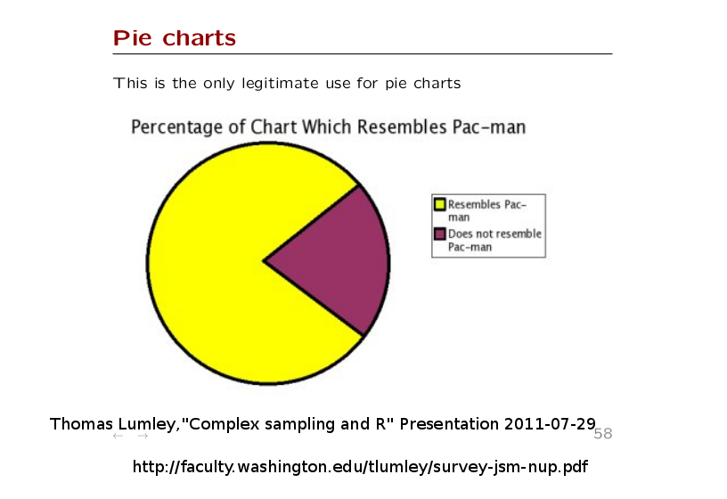

# What type of plot should you use?

- Pie charts are never a good choice.
- Bar plots for categorical data and histograms are better ways to present frequency though tables are probably a better choice for descriptive statistics.
- Scatterplots are useful to illustrate how two variables are changing (or not changing) together or to highlight a non-linear relationship that has been previously hypothesized as linear.
- In a journal article, you will probably be limited on the number of figures you can submit with the article. Do you want to waste one on descriptive information?
- What type of figures do other people use in articles similar to the one you are writing?
- How is the picture going to help the reader understand the story you are telling?

# What labels should you choose?

- By default, R provides no title and the variable names as the labels or other predefined values.

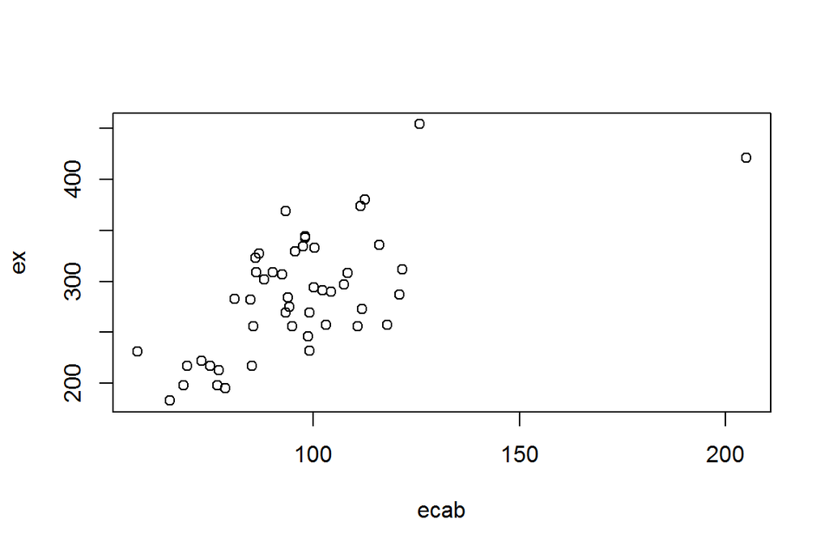

```r
plot(ex ~ ecab, data = lab5)
```

# Labels

- Use xlab and ylab to change your axis labels to something that does not require knowledge of your data set to understand.
- Should you include a title within the plot itself? It depends on the publishing guidelines you are following. APA guidelines instructs you to crop any titles out so that the title is in the text of the document.
- If the plot is for a poster or other presentation, you might want to include a title.

# And a legend

- Legends can be placed inside a plot or in the margins with inset

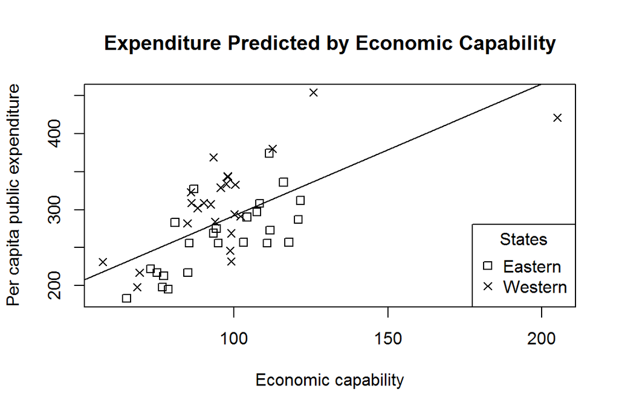

```r
plot(ex ~ ecab, xlab = "Economic capability", ylab = "Per capita public expenditure",
     main = "Expenditure Predicted by Economic Capability", type = "n", data = lab5)
with(lab5[lab5$west == 0, ], points(ecab, ex, pch = 0))
with(lab5[lab5$west != 0, ], points(ecab, ex, pch = 4))
abline(mod1)
legend("bottomright",legend=c("Eastern", "Western"), pch=c(0,4), title = "States")
```

# How should you size the figure?

# Fonts and colors

- The default fonts and colors might not be what you want.
- If you are producing a figure to submit to a journal, check their guidelines on figures.
  - Some journals will not accept figures with colors (or will send the bill to you for printing) so you will need to think about different shades of gray instead of colors.
- Fonts need to be picked carefully as well.
  - APA guidelines call for san serif fonts (Times New Roman has serifs and Arial is san serif); R defaults to a san serif font in its plots.
  - The font can range from 8-12 points. Make sure it is big enough to be readable.

# Different R options

- RStudio will place the figure in the Plots window, sized to what is on the screen.
- When you want to produce a higher quality graphic, set it up, view it, and then output the graphic directly to another format with size explicitly set.
- For better viewing when creating a graphic, use Emacs + R, Notepad++, or R itself.
  - Creating a graphic will launch a separate graphics viewer.

# Saving to PDF

- To save a plot to an external file:

```r
pdf("SampleGraph.pdf", width=7.5, height=5)
plot(ex ~ ecab, xlab = "Economic capability", ylab = "Per capita public expenditure",
     main = "Expenditure Predicted by Economic Capability", type = "n", data = lab5)
with(lab5[lab5$west == 0, ], points(ecab, ex, pch = 0))
with(lab5[lab5$west != 0, ], points(ecab, ex, pch = 4))
abline(mod1)
legend("bottomright",legend=c("Eastern", "Western"), pch=c(0,4), title = "States")
dev.off()
```